# Moon Rover Autonomous Navigation

Author

Jorge Bris Moreno

## In Progress

### Short description:

This project, inspired by our final project found in the tabs below, focusses on automating the movement of a lunar rover accross the South Pole of the Moon. After talking to researchers at NASA about their work, we discovered that the South Pole of the Moon is a region of high interest for future lunar exploration. However, due to the extreme temperatures, it is not accessible to humans. Thus, with this project we aim to automate the movement of a lunar rover accross the moon in a safely manner while also accounting for the battery usage with the main goal of reaching areas of interest.

Another part of the project will be expanding the gridworld project to search for different resources on the moon once the rover has reached the desired destination (through the algorithm proposed in the project below).

I want to also give a special thank you to Dr. James Hickman who has been supervising this project and provided me with a lot of feedback and suggestions.

## Environment

The environment will use the file LDEM_80s_20MPP_ADJ from https://pgda.gsfc.nasa.gov/products/90 as our main terrain data. It has a resolution of 20 m/pixel. We will convert it into a quasicontinuous terrain in order to treat it as a continuous terrain and set the problem as a continuous control problem. Everything else will be modeled to follow the recommendations obtained by Dr. Prabal Saxena and other members of his team at NASA.

**Picture of the environment:**

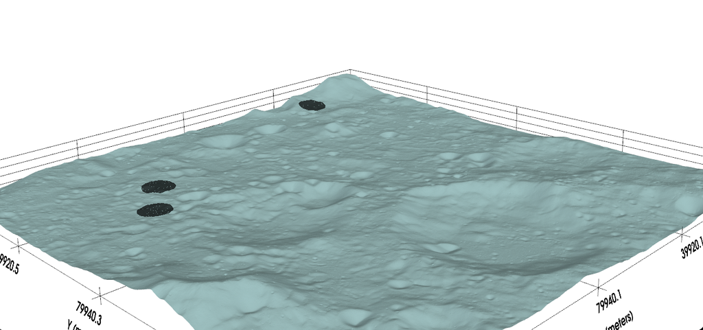

## Description of the steps:

We will train an RL algorithm to allow the rover to navigate safely and efficiently accross the moon. To do so, we have created different checkpoints to ensure the feasability of the projects while also being able to adapt to the different scenarios that we may face. Furthermore, each checkpoint trains the algorithm for different distances in an increasing order, to allow the algorithm to train with sparse rewards and complex decision making.

We will also check the response of the algorithm and compare it to the theoretical response of the rover. Since we are modeling the obstacles, the terrain, etc, we will run the A* algorithm to find the shortest path and compare it to the path found by the RL algorithm. While the rover might not see the every single problem in the map, and the A* algorithm will not take into account certain problems such as battery usage, it will allow us to have a baseline to compare the results to.

**Picture of the A* algorithm:**

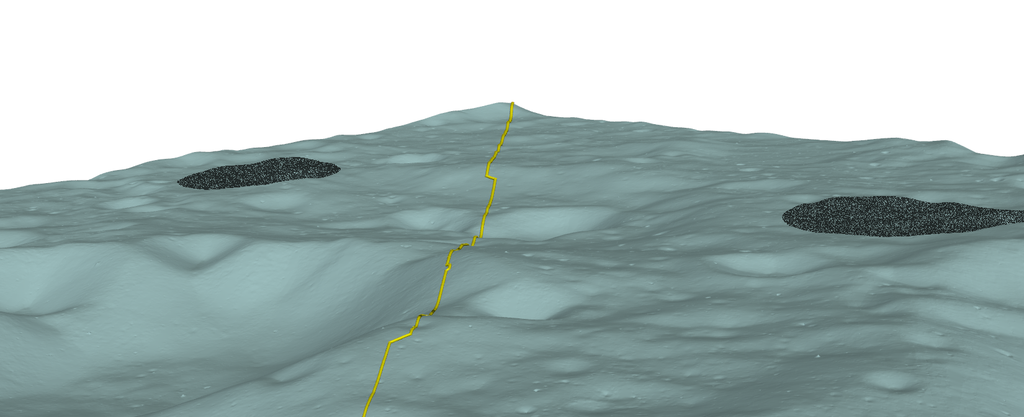

## Checkpoints

### Checkpoint 1:

In this checkpoint, we will train the algorithm to navigate safely accross the moon.

The first step in the development of this system will involve utilizing the terrain data with no additional information. Here, we will use this data to find the shortest and safest (meaning it has slopes of less than 25 degrees, lateral and frontwise) path to the destination by leveraging the A* algorithm. At this point, we will train an RL algorithm to get to that destination and contrast the results with one another, looking at their main differences in pathfinding and time to reach the destination to make improvements.

**Agent information, movement, and failure:**

- Agent information (normalized): Distance to the destination, and angle to the destination, current inclination, surrounding inclination, distance to the nearest cold trap, and angle to the nearest cold trap
- Actions: Move foward and full 360 degree turn.
- Failure: The rover crashes if it goes through a slope greater than 25 degrees or steps in a “cold trap” (a region of low temperature that is dangerous for the rover).

### Checkpoint 2: Battery Addition (destination is always fixed)

In this checkpoint, we will add the battery usage to the rover’s actions, battery recharge based on the light obtained by the rover’s solar pannels, and a battery usage based on temperature (based on light levels and the base temperature of theSouth Pole of the Moon).

**Agent information, movement, and failure:**

- Agent information (normalized): Same as checkpoint 1, but now with the addition of battery level, current light, surrounding light, batttery level.
- Actions: Move foward and full 360 degree turn.
- Failure: The rover crashes if it goes through a slope greater than 25 degrees or steps in a “cold trap” (a region of low temperature that is dangerous for the rover).

### Checkpoint 3: Obstacles and failure Addition (destination is always fixed)

Once the RL solver works for 1, we will still use the safe shortest path as a baseline for this step. However, here we will add obstacles (rocks) to the terrain that the rover may or may not perceive based on a probability (mimicking sensor errors). The rover will receive a negative reward if it crashes into an obstacle and it will be considered a crash after X number of crashes.

Additionally, tilting over will not be deterministic anymore. Instead, it will be safe to run the rover on slopes up to 27 degrees, and then the probability of tilting will follow a sigmoidal function from 27 degrees to 37 degrees, where at 37 degrees the probability of tilting is 1.

**Agent information, movement, and failure:**

- Agent information (normalized): Same as checkpoint 2, but now with the addition of surrounding rocks (with probability of being perceived).
- Actions: Move foward and full 360 degree turn.
- Failure: The rover crashes if it tilts, steps in a “cold trap”, or runs into X number of rocks.

### Checkpoint 4: Acceleration (destination is always fixed)

**Agent information, movement, and failure:**

- Agent information (normalized): Same as checkpoint 3.
- Actions: Accelerate (continuous), decelerate (continuous), and full 360 degree turn.
- Failure: The rover crashes if it tilts, steps in a “cold trap”, or runs into X number of rocks.

### Checkpoint 5: Input noise (destination is always fixed)

In this step, we will add noise to the rover’s inputs to simulate sensor errors. This will make the rover’s perception of its surroundings less accurate and will require it to rely more on its own actions and decisions. The noise will be added to the rover’s position, and surrounding inclination. Everything else will remain the same as in the previous checkpoint.

### Checkpoint 6: Different Destinations

**Agent information, movement, and failure:**

- Agent information (normalized): Distance to the destination, and angle to the destination, current inclination, surrounding inclination, current light, surrounding light, battery level, surrounding rocks (with probability of being perceived), distance to the nearest cold trap, and angle to the nearest cold trap.
- Actions: Accelerate (continuous), decelerate (continuous), and full 360 degree turn.
- Failure: The rover crashes if it tilts, steps in a “cold trap”, or runs into X number of rocks.

### Proposed algorithms

- SAC (with different configurations)
- TD3
- If needed, policy network can be adjusted to a different architecture (but we propose to use it out of the box first with different number of layers and neurons).
- Different hyperparameter choices have and will be made for each checkpoint and desired distance